# Week12_IP

Stacy Mwende

#Context A Kenyan entrepreneur has created an online cryptography course and would want to advertise it on her blog. She currently targets audiences originating from various countries. In the past, she ran ads to advertise a related course on the same blog and collected data in the process. She would now like to employ your services as a Data Science Consultant to help her identify which individuals are most likely to click on her ads.

#Defining the question Identify the target group in this case, which the individuals who are likely to click on her ad

#Metric for success Get the best variables that should be considered while posting the add to be enable maximum views which will translate to more people enrolling for the course.

#Experimental Design I undertook three steps in my project: Planning > Design >Analysis

#Loading the dataset ##Get the directory for the dataset

```r
getwd()
```

```
## [1] "C:/Users/comp5/Downloads/R_Program"
```

###Reading the dataset

```r
advertise <- read.csv("advertising.csv")
head(advertise)
```

```
##   Daily.Time.Spent.on.Site Age Area.Income Daily.Internet.Usage
## 1                    68.95  35    61833.90               256.09
## 2                    80.23  31    68441.85               193.77
## 3                    69.47  26    59785.94               236.50
## 4                    74.15  29    54806.18               245.89
## 5                    68.37  35    73889.99               225.58
## 6                    59.99  23    59761.56               226.74
##                           Ad.Topic.Line           City Male    Country
## 1    Cloned 5thgeneration orchestration    Wrightburgh    0    Tunisia
## 2    Monitored national standardization      West Jodi    1      Nauru
## 3      Organic bottom-line service-desk       Davidton    0 San Marino
## 4 Triple-buffered reciprocal time-frame West Terrifurt    1      Italy
## 5         Robust logistical utilization   South Manuel    0    Iceland
## 6       Sharable client-driven software      Jamieberg    1     Norway
##             Timestamp Clicked.on.Ad
## 1 2016-03-27 00:53:11             0
## 2 2016-04-04 01:39:02             0
## 3 2016-03-13 20:35:42             0
## 4 2016-01-10 02:31:19             0
## 5 2016-06-03 03:36:18             0
## 6 2016-05-19 14:30:17             0
```

#Getting more information about the dataset

```r
nrow(advertise)
```

```
## [1] 1000
```

The dataset has 1000 entries

```r
NCOL(advertise)
```

```
## [1] 10
```

The dataset has a total of 10 columns

#Data Cleaning ##Checking for null values

```r
sum(is.na(advertise))
```

```
## [1] 0
```

There is no missing data in the dataset provided for analysis

##Checking for duplicates

```r
duplicated_adv <- advertise[duplicated(advertise),]
duplicated_adv
```

```
##  [1] Daily.Time.Spent.on.Site Age
##  [3] Area.Income              Daily.Internet.Usage
##  [5] Ad.Topic.Line            City
##  [7] Male                     Country
##  [9] Timestamp                Clicked.on.Ad
## <0 rows> (or 0-length row.names)
```

There are no duplicates in the dataset

##Checking for outliers

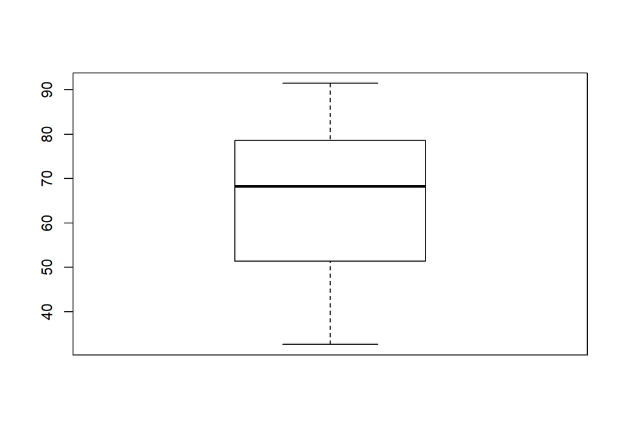

```r
OutVals = boxplot(advertise$
Daily.Time.Spent.on.Site)
```

There are no outliers in the Daily.Time.Spent.on.Site column

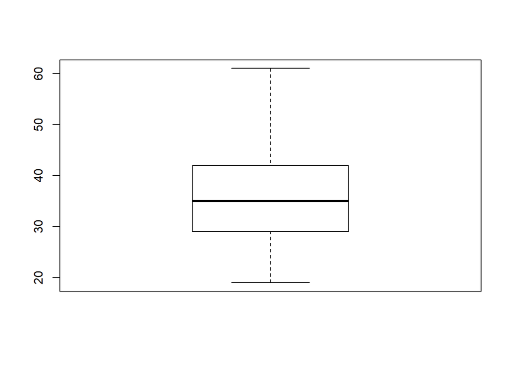

```r
OutVals = boxplot(advertise$Age)
```

No outliers in the Age column

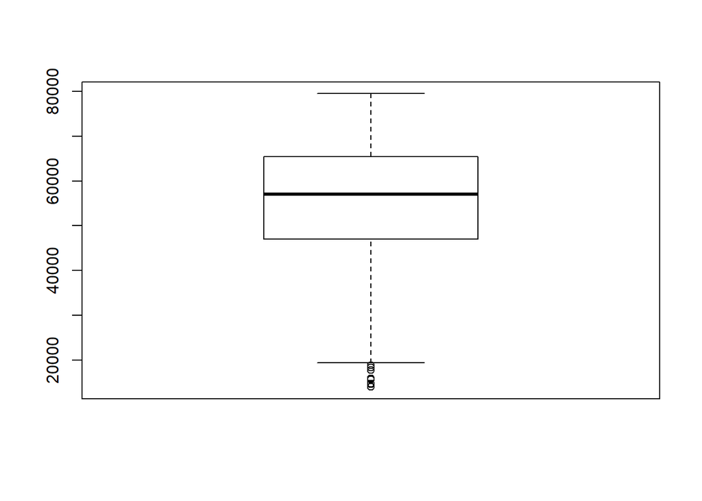

```r
OutVals = boxplot(advertise$Area.Income)
```

There are outliers in the Area.Income column.

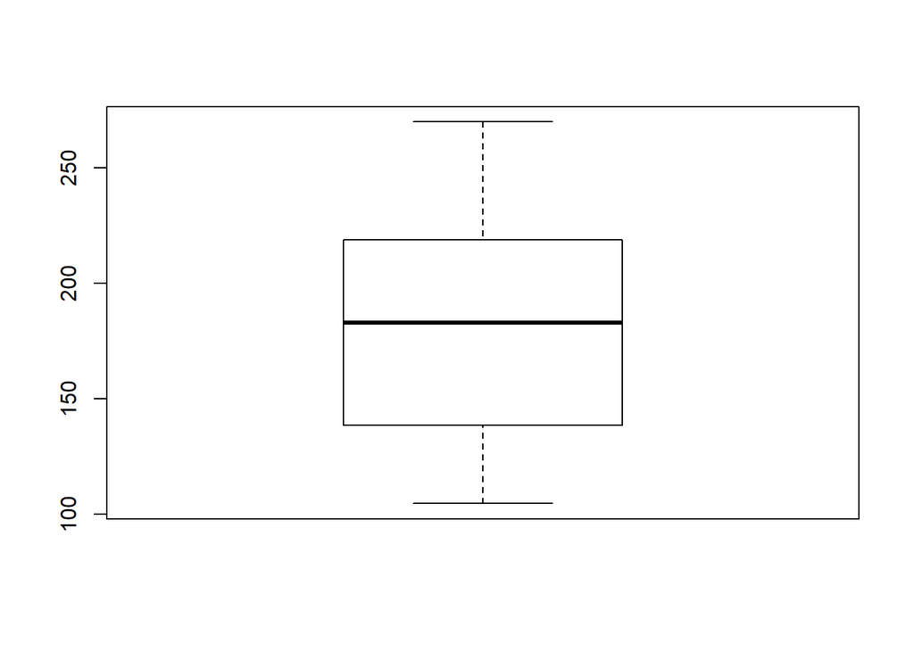

```r
OutVals = boxplot(advertise$
Daily.Internet.Usage)
```

There are no outliers in the Daily internet usage column

#Correcting wrongly labeled columns Get the column names

```r
colnames(advertise)
```

```
##  [1] "Daily.Time.Spent.on.Site" "Age"
##  [3] "Area.Income"              "Daily.Internet.Usage"
##  [5] "Ad.Topic.Line"            "City"
##  [7] "Male"                     "Country"
##  [9] "Timestamp"                "Clicked.on.Ad"
```

The column labelled Male should be Gender which will consist of Male and Female

```r
names(advertise)[names(advertise) == "Male"] <- "Gender"
```

```r
colnames(advertise)
```

```
##  [1] "Daily.Time.Spent.on.Site" "Age"
##  [3] "Area.Income"              "Daily.Internet.Usage"
##  [5] "Ad.Topic.Line"            "City"
##  [7] "Gender"                   "Country"
##  [9] "Timestamp"                "Clicked.on.Ad"
```

The column has been renamed to Gender as observed above

**Checking if the data is balanced** We consider our target variable i.e Clicked.on.Ad

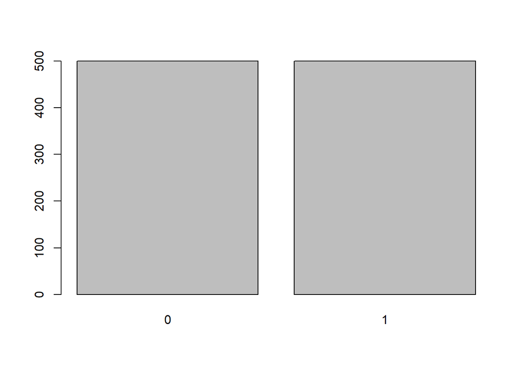

```r
Clicked.on.Ad_freq <- table(advertise$Clicked.on.Ad)
barplot(Clicked.on.Ad_freq)
```

For the visualization above, the data is balanced in that equal number of people viewed and also an equal number did not view the Ad.

#Getting a Summary of the dataset

```r
summary(advertise)
```

```
##  Daily.Time.Spent.on.Site      Age         Area.Income
##  Min.   :32.60            Min.   :19.00   Min.   :13996
##  1st Qu.:51.36            1st Qu.:29.00   1st Qu.:47032
##  Median :68.22            Median :35.00   Median :57012
##  Mean   :65.00            Mean   :36.01   Mean   :55000
##  3rd Qu.:78.55            3rd Qu.:42.00   3rd Qu.:65471
##  Max.   :91.43            Max.   :61.00   Max.   :79485
##
##  Daily.Internet.Usage                                 Ad.Topic.Line
##  Min.   :104.8        Adaptive 24hour Graphic Interface      :  1
##  1st Qu.:138.8        Adaptive asynchronous attitude         :  1
##  Median :183.1        Adaptive context-sensitive application :  1
##  Mean   :180.0        Adaptive contextually-based methodology:  1
##  3rd Qu.:218.8        Adaptive demand-driven knowledgebase   :  1
##  Max.   :270.0        Adaptive uniform capability            :  1
##                       (Other)                                :994
##               City         Gender                Country
##  Lisamouth      :  3   Min.   :0.000   Czech Republic:  9
##  Williamsport   :  3   1st Qu.:0.000   France        :  9
##  Benjaminchester:  2   Median :0.000   Afghanistan   :  8
##  East John      :  2   Mean   :0.481   Australia     :  8
##  East Timothy   :  2   3rd Qu.:1.000   Cyprus        :  8
##  Johnstad       :  2   Max.   :1.000   Greece        :  8
##  (Other)        :986                   (Other)       :950
##                Timestamp   Clicked.on.Ad
##  2016-01-01 02:52:10:  1   Min.   :0.0
##  2016-01-01 03:35:35:  1   1st Qu.:0.0
##  2016-01-01 05:31:22:  1   Median :0.5
##  2016-01-01 08:27:06:  1   Mean   :0.5
##  2016-01-01 15:14:24:  1   3rd Qu.:1.0
##  2016-01-01 20:17:49:  1   Max.   :1.0
##  (Other)            :994
```

The summary code gives us a couple of outputs including Minimum,1st quartile,Median,Mean,3rd Quartile and the Maximum value. The different variables are distributed with the above stated output.

**Checking the country that had more people visit the site**

```r
library(pander)
library(dplyr)
advertise %>%
    group_by(Country) %>%
    summarize(frequency = n()) %>%
    arrange(desc(frequency)) %>%
    mutate(relative_frequency = frequency/sum(frequency)) %>%
    pander
```

| Country | frequency | relative_frequency |
| --- | --- | --- |
| Czech Republic | 9 | 0.009 |
| France | 9 | 0.009 |
| Afghanistan | 8 | 0.008 |
| Australia | 8 | 0.008 |
| Cyprus | 8 | 0.008 |
| Greece | 8 | 0.008 |
| Liberia | 8 | 0.008 |
| Micronesia | 8 | 0.008 |
| Peru | 8 | 0.008 |
| Senegal | 8 | 0.008 |
| South Africa | 8 | 0.008 |
| Turkey | 8 | 0.008 |
| Albania | 7 | 0.007 |
| Bahamas | 7 | 0.007 |
| Bosnia and Herzegovina | 7 | 0.007 |
| Burundi | 7 | 0.007 |
| Cambodia | 7 | 0.007 |
| Eritrea | 7 | 0.007 |
| Ethiopia | 7 | 0.007 |
| Fiji | 7 | 0.007 |
| Luxembourg | 7 | 0.007 |
| Taiwan | 7 | 0.007 |
| Venezuela | 7 | 0.007 |
| Western Sahara | 7 | 0.007 |
| Algeria | 6 | 0.006 |
| Anguilla | 6 | 0.006 |
| Belarus | 6 | 0.006 |
| Bolivia | 6 | 0.006 |
| Bulgaria | 6 | 0.006 |
| China | 6 | 0.006 |

[output cut: 207 more lines]

Czech Republic, France topped the list with Afghanistan and Australia following in the second place and the rest of the countries followed in order.

#Performing Exploratory Data Analysis ##Univariate Analysis Covert the dataframe to tibble for easier analysis

```r
library("tibble")
my_data <- as_tibble(advertise)
class(my_data)
```

```
## [1] "tbl_df"     "tbl"        "data.frame"
```

###Measures of Central Tendency 1.*Mean*

```r
mean(advertise$Daily.Time.Spent.on.Site)
```

```
## [1] 65.0002
```

People avearagely spent 65 minutes per day on the the site

```r
mean(advertise$Area.Income)
```

```
## [1] 55000
```

Average area income is 55,000 from the considered dataset

```r
mean(advertise$Daily.Internet.Usage)
```

```
## [1] 180.0001
```

Most people used an average of 180MBs per day on the very website in consideration

```r
library(dplyr)
library(pander)
my_data %>%
    summarize(variable = "Age", mean_age = mean(Age), st_dev_age = sd(Age)) %>%
    pander
```

| variable | mean_age | st_dev_age |
| --- | --- | --- |
| Age | 36.01 | 8.786 |

Mean age of the people who visited the site was 36 years of age with a spread of 8 from the mean

*Getting a quartile distribution of the Age column*

```r
my_data %>%
    summarize(variable = "Age",
              q0.25 = quantile(Age, 0.25),
              q0.50 = quantile(Age, 0.50),
              q0.75 = quantile(Age, 0.75),
              q1 = quantile(Age, 1)) %>%
    pander
```

| variable | q0.25 | q0.50 | q0.75 | q1 |
| --- | --- | --- | --- | --- |
| Age | 29 | 35 | 42 | 61 |

*Visualizing the above age column in a ggplot as shown below*

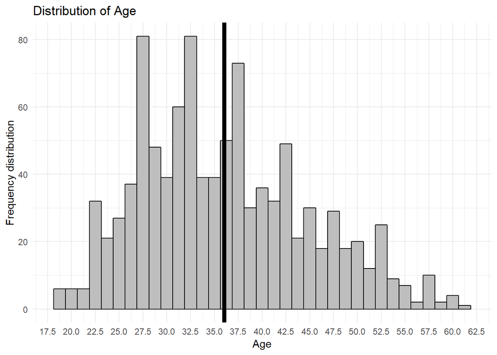

```r
install.packages("ggplot2")
library("ggplot2")
library(dplyr)
my_data %>%
    ggplot(aes(Age)) +
    geom_histogram(binwidth = 1.25, color = "black",fill = "grey") +
    geom_vline(xintercept = mean(my_data$Age), lwd = 2) +
    labs(title = "Distribution of Age",
         x = "Age",
         y = "Frequency distribution") +
    theme_minimal() +
    scale_x_continuous(breaks = seq(7.5,100,2.5))
```

###Bar Graph *Gender Column*

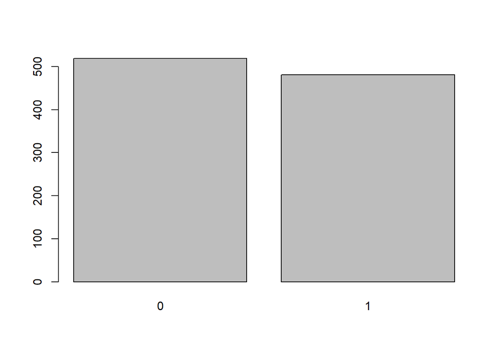

```r
Gender <- my_data$Gender
Gender_freq <- table(Gender)
barplot(Gender_freq)
```

From the visualization above, more females(0) visited the site compare to male counterparts(1)

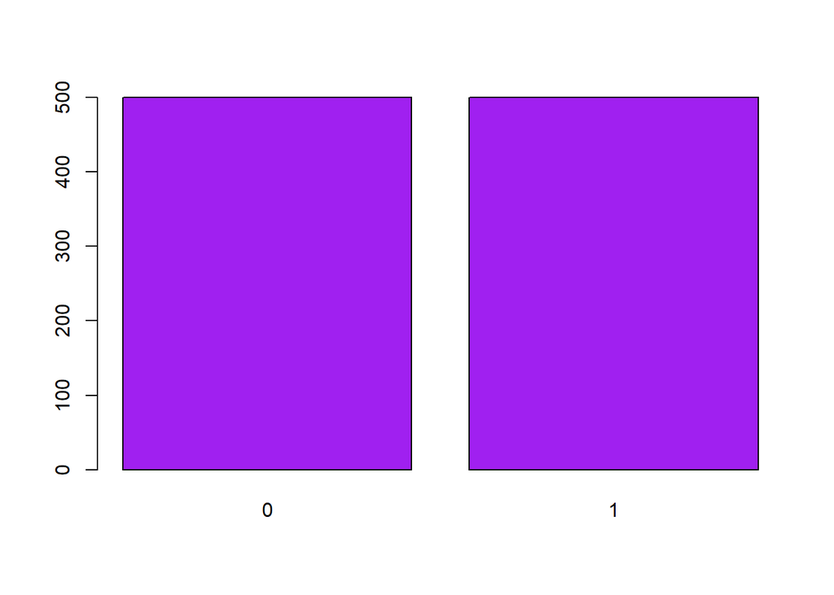

```r
Clicked.on.Ad <- my_data$Clicked.on.Ad
Clicked.on.Ad_freq <- table(Clicked.on.Ad)
barplot(Clicked.on.Ad_freq, col = "purple")
```

The visualization above shows that there was equal distribution of the people who either viewed or did not view on the add.

###Histogram

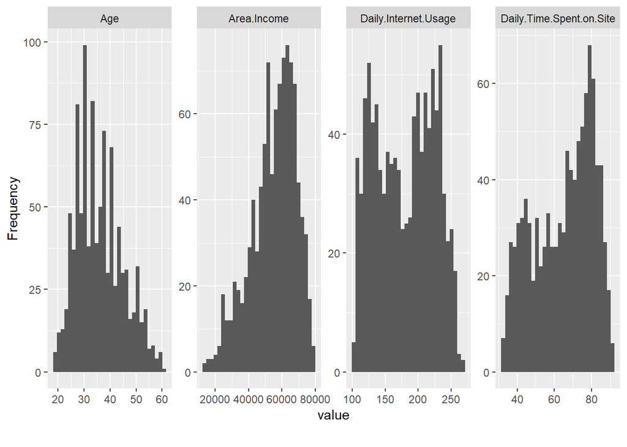

```r
library(DataExplorer)
plot_histogram(my_data)
```

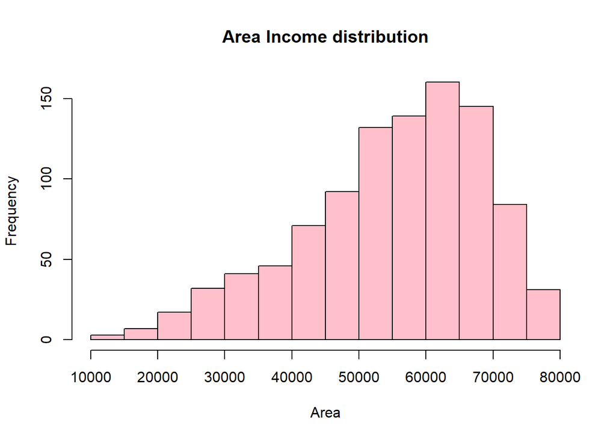

```r
z = hist(my_data$Area.Income,
         main = "Area Income distribution",
         xlab = "Area",
         col = "pink"
         )
```

##Bivariate Analysis *Covariance* Covariance is a number that reflects the degree to which two variable vary together **Daily.Time.Spent.on.Site Vs Age**

```r
Daily.Time.Spent.on.Site <- my_data$Daily.Time.Spent.on.Site
Age <- my_data$Age
cov(Daily.Time.Spent.on.Site, Age)
```

```
## [1] -46.17415
```

The above value indicates that there is a negative correlation between the 2 variables. This means that a change in either variable leads to a decrease in the other.

**Age Vs Gender**

```r
Age <- my_data$Age
Gender <- my_data$Gender
cov(Age, Gender)
```

```
## [1] -0.09242142
```

There is a negative relation between the 2 variables though not so big.

**Clicked.on.Ad Vs Age**

```r
Clicked.on.Ad <- my_data$Clicked.on.Ad
Age <- my_data$Age
cov(Clicked.on.Ad, Age)
```

```
## [1] 2.164665
```

There is a positive relation between the 2 variables, in that an increase in one would increase the value of the other.

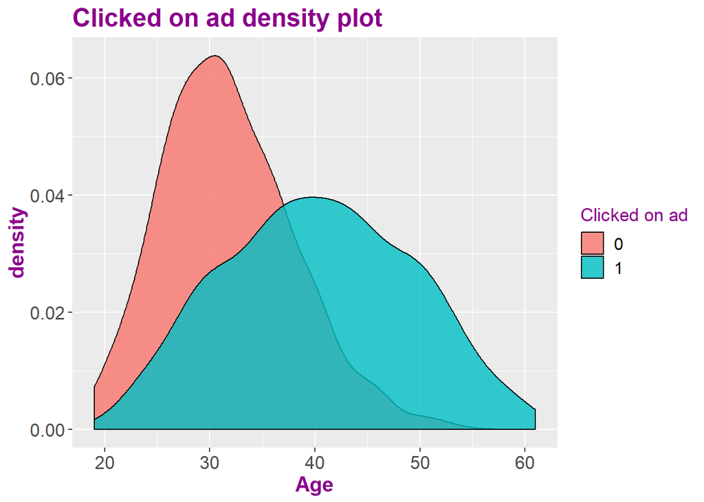

```r
library(ggplot2)
options(repr.plot.width = 13, repr.plot.height = 7)
R2 = ggplot(data = my_data, aes(Age)) +
        geom_density(aes(fill=factor(Clicked.on.Ad)), alpha = 0.8) +
        labs(title = 'Clicked on ad density plot', x = 'Age', fill = 'Clicked on ad') +
        scale_color_brewer(palette = 1) +
        theme(plot.title = element_text(size = 18, face = 'bold', color = 'darkmagenta'),
             axis.title.x = element_text(size = 15, face = 'bold', color = 'darkmagenta'),
             axis.title.y = element_text(size = 15, face = 'bold', color = 'darkmagenta'),
             axis.text.x = element_text(size = 13, angle = 0),
             axis.text.y = element_text(size = 13),
             legend.title = element_text(size = 13, color = 'darkmagenta'),
             legend.text = element_text(size = 12))

plot(R2)
```

#Multivariate Analysis

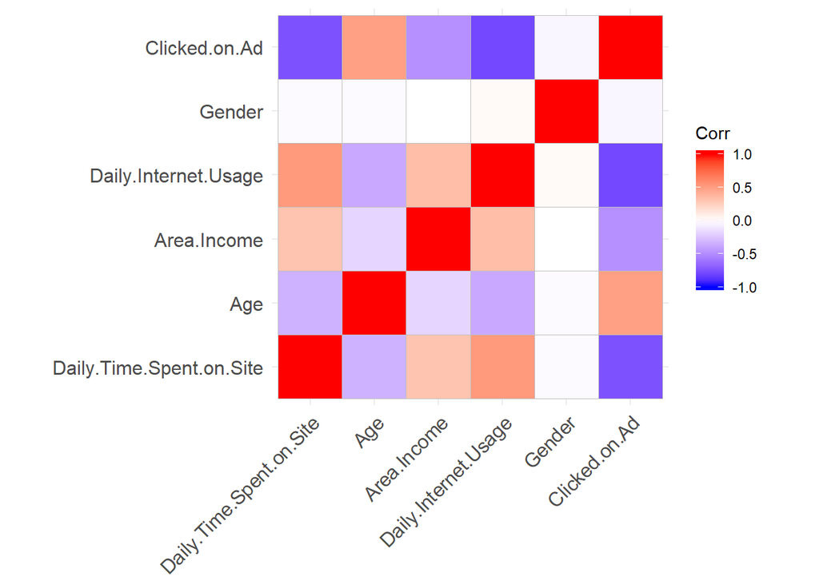

```r
library(ggcorrplot)
my_data %>%
    select_if(is.numeric) %>%
    cor %>%
    ggcorrplot()
```

There is a high correlation between a variable and it’s self which is normal There is also a highly relative correlation between DailyTimeSpentOnSite and the DailyInternetUsage We also observe a correlatio between Age and ClickedOnAd column There is no correlation between Gender and Age